# Project 1 : Working on the Mall Customers dataset

### The Mall Customers dataset serves as a valuable resource for businesses to gain insights into their customer base and make data-driven decisions to improve marketing strategies, enhance customer experiences, and drive business growth.

##### The goal of analyzing the Mall Customers dataset can vary depending on the objectives of the analysis, but some common objectives include:

1. **Customer Segmentation: **Identifying different groups or segments of customers based on their demographic and spending characteristics. This could help in targeted marketing efforts or personalized customer experiences.****
2. **Understanding Customer Behavior: **Analyzing patterns in customer spending behavior to understand preferences, trends, and factors influencing purchasing decisions.****

### In this project, I will be targeting these two(2) common objectives

## Mall Customers dataset with a Focus on Customer Segmentation

Identify distinct segments of customers based on demographic and spending characteristics to optimize marketing strategies and personalize customer experiences.

Approach:

Utilize clustering algorithms such as K-means, DBSCAN, or hierarchical clustering to group customers with similar attributes together. Analyze the characteristics of each segment to understand their unique preferences and behaviors. Develop targeted marketing campaigns and promotional offers tailored to each segment. Evaluate the effectiveness of segmentation strategies through metrics such as customer satisfaction, retention rates, and revenue growth. Impact on Job Search:

Showcase your expertise in unsupervised learning techniques and data-driven segmentation strategies. Highlight your ability to translate insights into actionable marketing strategies that drive business growth and customer engagement. Provide concrete examples of how your segmentation approach has successfully improved marketing effectiveness or customer satisfaction in previous roles or projects.

Importing necessary packages

```python
import numpy as np
import pandas as pd
import matplotlib.pyplot as plt
import seaborn as sns
from sklearn.cluster import KMeans
from sklearn.preprocessing import StandardScaler
```

### Import dataset

```python
mall_customers=pd.read_csv('../Data/Mall_Customers.csv')
print(mall_customers.head())
#Summary statisctics
print(f"The summary statistics\n {mall_customers.describe()}")
#Checking for missing values
print(f"Checking for missing values \n {mall_customers.isnull().sum()}")
```

```
   CustomerID   Genre  Age  Annual Income (k$)  Spending Score (1-100)
0           1    Male   19                  15                      39
1           2    Male   21                  15                      81
2           3  Female   20                  16                       6
3           4  Female   23                  16                      77
4           5  Female   31                  17                      40
The summary statistics
        CustomerID         Age  Annual Income (k$)  Spending Score (1-100)
count  200.000000  200.000000          200.000000              200.000000
mean   100.500000   38.850000           60.560000               50.200000
std     57.879185   13.969007           26.264721               25.823522
min      1.000000   18.000000           15.000000                1.000000
25%     50.750000   28.750000           41.500000               34.750000
50%    100.500000   36.000000           61.500000               50.000000
75%    150.250000   49.000000           78.000000               73.000000
max    200.000000   70.000000          137.000000               99.000000
Checking for missing values
 CustomerID                0
Genre                     0
Age                       0
Annual Income (k$)        0
Spending Score (1-100)    0
dtype: int64
```

### Data Distribution visualization

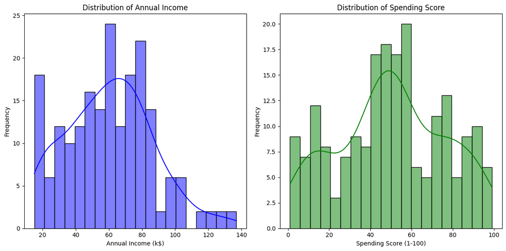

```python
plt.figure(figsize=(12, 6))
plt.subplot(1, 2, 1)
sns.histplot(mall_customers['Annual Income (k$)'], bins=20, kde=True, color='blue')
plt.title('Distribution of Annual Income')
plt.xlabel('Annual Income (k$)')
plt.ylabel('Frequency')

plt.subplot(1, 2, 2)
sns.histplot(mall_customers['Spending Score (1-100)'], bins=20, kde=True, color='green')
plt.title('Distribution of Spending Score')
plt.xlabel('Spending Score (1-100)')
plt.ylabel('Frequency')

plt.tight_layout()
plt.show()
```

### CLustering

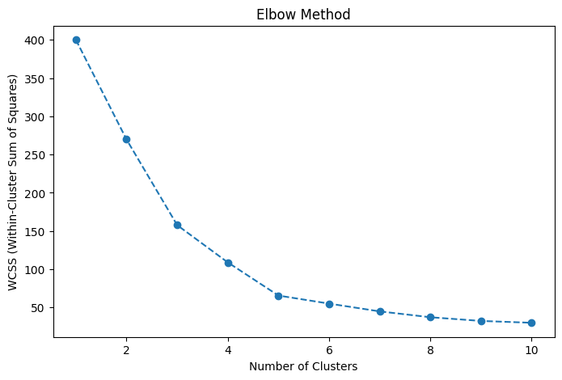

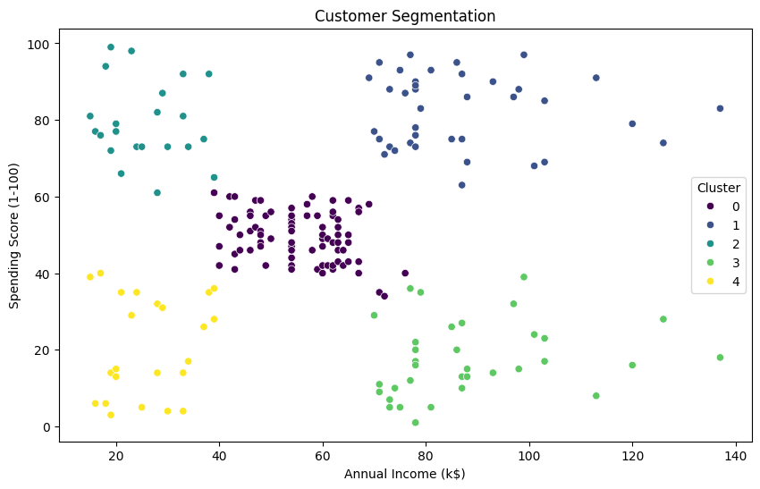

```python
# Feature scaling
scaler = StandardScaler()
scaled_data = scaler.fit_transform(mall_customers[['Annual Income (k$)', 'Spending Score (1-100)']])

# Determine optimal number of clusters using the elbow method
wcss = []
for i in range(1, 11):
    kmeans = KMeans(n_clusters=i, init='k-means++', random_state=42)
    kmeans.fit(scaled_data)
    wcss.append(kmeans.inertia_)

# Plot the elbow curve
plt.figure(figsize=(8, 5))
plt.plot(range(1, 11), wcss, marker='o', linestyle='--')
plt.title('Elbow Method')
plt.xlabel('Number of Clusters')
plt.ylabel('WCSS (Within-Cluster Sum of Squares)')
plt.show()

# Fit K-means clustering algorithm with the optimal number of clusters
kmeans = KMeans(n_clusters=5, init='k-means++', random_state=42)
mall_customers['Cluster'] = kmeans.fit_predict(scaled_data)

# Visualize the clusters
plt.figure(figsize=(10, 6))
sns.scatterplot(data=mall_customers, x='Annual Income (k$)', y='Spending Score (1-100)', hue='Cluster', palette='viridis', legend='full')
plt.title('Customer Segmentation')
plt.xlabel('Annual Income (k$)')
plt.ylabel('Spending Score (1-100)')
plt.show()
```

Further Descriptive clustering

```
Cluster Centers:
   Annual Income (k$)  Spending Score (1-100)
0           -0.200913               -0.026456
1            0.991583                1.239503
2           -1.329545                1.132178
3            1.055003               -1.284439
4           -1.307519               -1.136965

Cluster Sizes:
Cluster
0    81
1    39
3    35
4    23
2    22
Name: count, dtype: int64
```

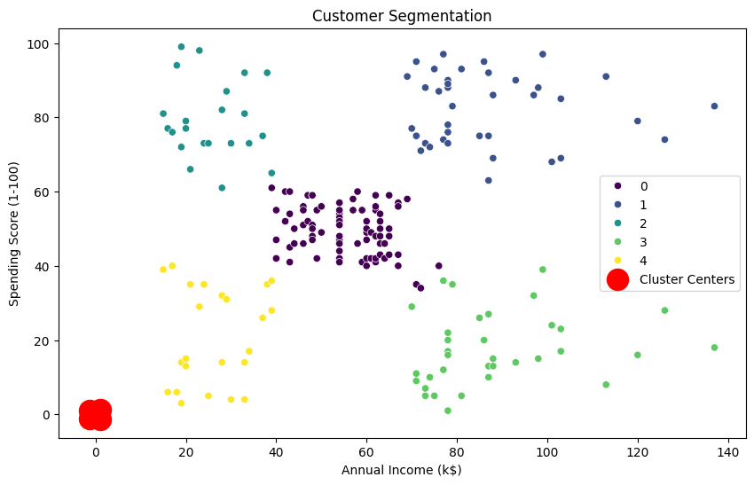

```python
# Fit K-means clustering algorithm with the optimal number of clusters
kmeans = KMeans(n_clusters=5, init='k-means++', random_state=42)
mall_customers['Cluster'] = kmeans.fit_predict(scaled_data)

# Display cluster centers
cluster_centers = pd.DataFrame(kmeans.cluster_centers_, columns=['Annual Income (k$)', 'Spending Score (1-100)'])
print("Cluster Centers:")
print(cluster_centers)

# Display cluster sizes
print("\nCluster Sizes:")
print(mall_customers['Cluster'].value_counts())

# Visualize the clusters
plt.figure(figsize=(10, 6))
sns.scatterplot(data=mall_customers, x='Annual Income (k$)', y='Spending Score (1-100)', hue='Cluster', palette='viridis', legend='full')
plt.scatter(cluster_centers['Annual Income (k$)'], cluster_centers['Spending Score (1-100)'], s=300, c='red', marker='o', label='Cluster Centers')
plt.title('Customer Segmentation')
plt.xlabel('Annual Income (k$)')
plt.ylabel('Spending Score (1-100)')
plt.legend()
plt.show()
```

Clustering analysis reveals segments where there are customers who earn relatively low incomes but still exhibit high spending behavior, as well as customers with high incomes who are conservative spenders. This complexity in customer behavior is precisely why clustering is valuable—it helps identify patterns and segments that might not be immediately obvious from simple demographic characteristics.

Here's what we're gaining from the clustering analysis despite these complexities:

1. **Segment Identification:** Clustering helps identify these nuanced segments within the customer base. Even if some segments may not fit neatly into our preconceived notions based on income or spending behavior alone, clustering allows us to uncover these hidden patterns.
2. **Understanding Behavioral Patterns:** By analyzing these clusters, businesses can gain deeper insights into the underlying behavioral patterns driving customer spending. For example, in segments where customers earn low incomes but still spend heavily, there might be factors like lifestyle choices, financial priorities, or even cultural influences at play.
3. **Targeted Marketing Opportunities:** Despite the complexities, clustering still allows businesses to target specific customer segments with tailored marketing strategies. For instance, even if a segment contains customers with varying income and spending levels, there might be commonalities in their preferences or purchase motivations that businesses can leverage in their marketing efforts.
4. **Personalization and Customization:** Clustering enables businesses to personalize their interactions and offerings for different segments. By understanding the unique characteristics and needs of each segment, businesses can deliver more relevant and targeted experiences, leading to higher customer satisfaction and loyalty.
5. **Optimizing Resource Allocation:** Clustering helps optimize resource allocation by directing marketing resources, sales efforts, and product development towards the segments with the greatest potential for ROI. This ensures that limited resources are allocated efficiently to maximize impact and profitability.

In essence, while clustering may reveal complex and nuanced segments that defy simplistic categorization based on income or spending behavior alone, it still provides valuable insights that businesses can leverage to better understand their customers and tailor their strategies accordingly. By embracing this complexity and embracing the insights derived from clustering, businesses can gain a competitive edge in meeting the diverse needs and preferences of their customer base.